# Introduction

## Goals and Perspective

In this project, six countries and their GDP will be analyzed. This project aims to identify the relationship between life expectancy and the GDP of a given country.

The `data in this project is based on real data and is not real`. It has been provided by Codecademy.

The perspective of this project will be that of a data analyst from the World Health Organization (WHO).

The project `seeks to answer the following questions`:

- Has life expectancy increased over time in the six nations?
- Has GDP increased over time in the six nations?
- Is there a correlation between GDP and life expectancy of a country?
- What is the average life expectancy in these nations?
- What is the distribution of that life expectancy?

The project will be broken down into 3 parts.

### Loading and Understanding the data

In this section, the data and be loaded, and explored for further use.

### Analysis

This section will answer the questions from the introduction

### Conclusion

Lastly, the practical use of the data will be discussed. As well as any pitfalls in the data or project.

# Loading and understanding the Data

This project will primarily use pandas and matplotlib to store and plot the data.

A `pandas dataframe or df for short`. Is a very powerful data structure that can be used to manipulate data.

The CSV file `all_data.csv` has 4 columns

- Country - The name of the country (in this file there are 6)
- Year - The year the GDP and life expectancy were recorded.
- Life expectancy - The life expectancy at birth (the number of years a person is expected to live)
- GDP - Gross domestic product (a measure of all services and goods produced in a country)

### Load python modules

```python
import pandas as pd
import matplotlib.pyplot as plt
import scipy.stats as st
```

### Use Pandas to load the csv file

```python
df = pd.read_csv(r'all_data.csv') # loads the file into a df
df # In Jy Notebook if the last line is a data structure you do not need print() it will print it
```

|  | Country | Year | Life expectancy at birth (years) | GDP |
| --- | --- | --- | --- | --- |
| 0 | Chile | 2000 | 77.3 | 7.786093e+10 |
| 1 | Chile | 2001 | 77.3 | 7.097992e+10 |
| 2 | Chile | 2002 | 77.8 | 6.973681e+10 |
| 3 | Chile | 2003 | 77.9 | 7.564346e+10 |
| 4 | Chile | 2004 | 78.0 | 9.921039e+10 |
| ... | ... | ... | ... | ... |
| 91 | Zimbabwe | 2011 | 54.9 | 1.209845e+10 |
| 92 | Zimbabwe | 2012 | 56.6 | 1.424249e+10 |
| 93 | Zimbabwe | 2013 | 58.0 | 1.545177e+10 |
| 94 | Zimbabwe | 2014 | 59.2 | 1.589105e+10 |
| 95 | Zimbabwe | 2015 | 60.7 | 1.630467e+10 |

96 rows × 4 columns

### Explore the data

First I am going to see if I need to clean the data. Panadas has many built in tools we can use.

```python
df.dtypes
```

```
Country                              object
Year                                  int64
Life expectancy at birth (years)    float64
GDP                                 float64
dtype: object
```

The columns we will need to be numbers(int or float) are already numbers. So do not need changed.

And there are 4 columns.

```python
df['Country'].unique()
```

```
array(['Chile', 'China', 'Germany', 'Mexico', 'United States of America',
       'Zimbabwe'], dtype=object)
```

There are 6 different countries in the country column.

```python
df.isnull().sum()
```

```
Country                             0
Year                                0
Life expectancy at birth (years)    0
GDP                                 0
dtype: int64
```

The data has no null values in any column.

```python
df['Year'].unique()
```

```
array([2000, 2001, 2002, 2003, 2004, 2005, 2006, 2007, 2008, 2009, 2010,
       2011, 2012, 2013, 2014, 2015], dtype=int64)
```

The data is from 2000-2015.

```python
df.describe()
```

|  | Year | Life expectancy at birth (years) | GDP |
| --- | --- | --- | --- |
| count | 96.000000 | 96.000000 | 9.600000e+01 |
| mean | 2007.500000 | 72.789583 | 3.880499e+12 |
| std | 4.633971 | 10.672882 | 5.197561e+12 |
| min | 2000.000000 | 44.300000 | 4.415703e+09 |
| 25% | 2003.750000 | 74.475000 | 1.733018e+11 |
| 50% | 2007.500000 | 76.750000 | 1.280220e+12 |
| 75% | 2011.250000 | 78.900000 | 4.067510e+12 |
| max | 2015.000000 | 81.000000 | 1.810000e+13 |

The overall mean life expectancy is around 73. The lowest is 44 and the highest is 81.

Considering the changes in the world economy between 2000 and 2015 these GDP numbers are very high. The overall mean GDP is 3.880499e+12 or 3,880,499,000,000.

Now that I have a general idea of what the data looks like. Let's analyze the data further.

# Analysis

In this section we will answer the questions from the introduction.

## Has life expectancy increased over time in the six nations?

This is the first question from the introduction. To show the trend of each nation I will create a line graph for all of them. Line graphs are one of the best graphs for showing change over time. Perfect for this question.

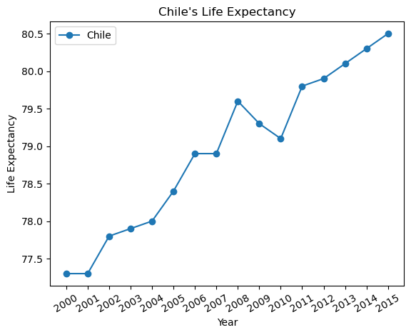

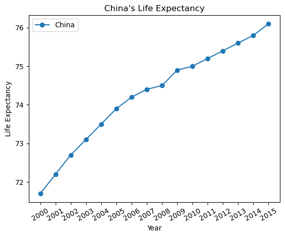

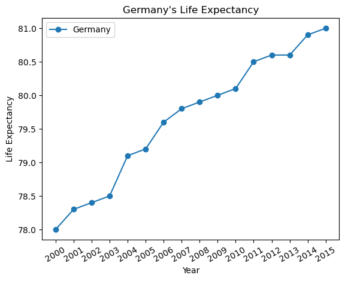

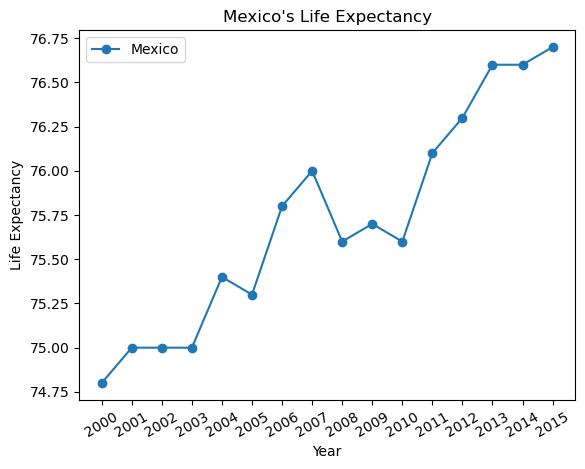

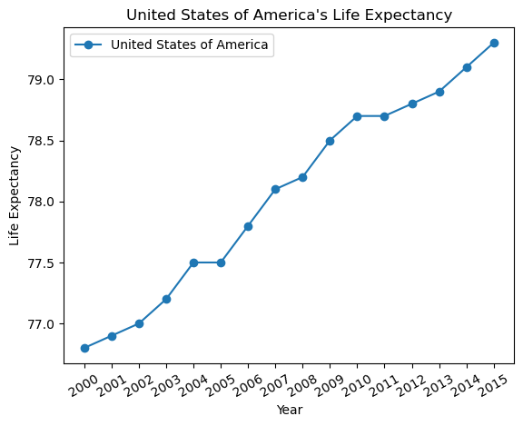

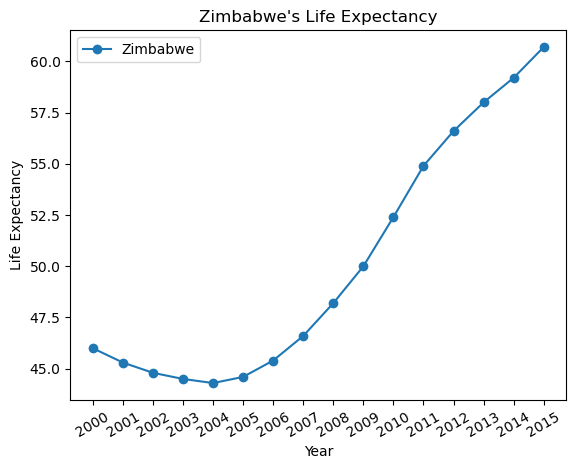

```python
years = df['Year'].unique() # all data is from 2000-2015
countries = df["Country"].unique() # list of all countries


for country in countries:
    data = df[df['Country'] == country]  # Filter data for each country
    plt.figure()
    #print(data)
    plt.plot(data["Year"], data["Life expectancy at birth (years)"], label=country, marker='o')  # Plot with dots and lines


    plt.xlabel("Year")
    plt.ylabel("Life Expectancy")
    plt.xticks(years, rotation=30)
    plt.title(f"{country}'s Life Expectancy")
    plt.legend()

    plt.show()
    plt.close()
```

Based on these graphs there is a strong increase in expected age for all countries in the years 2000-2015.

To better compare how the countries all increased over time. I am going to plot them together.

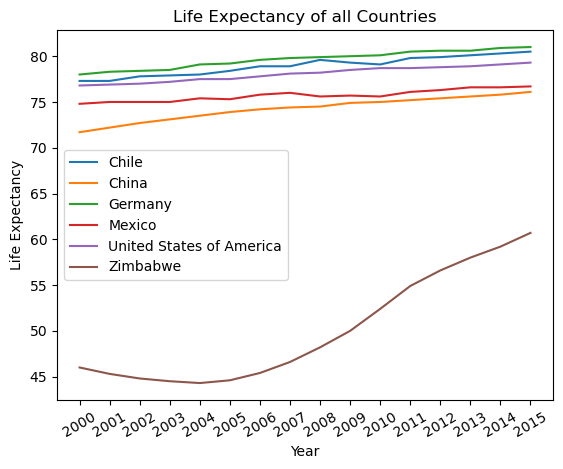

```python
for country in countries:
    data = df[df['Country'] == country]  # Filter data for each country
    #print(data)
    plt.plot(data["Year"], data["Life expectancy at birth (years)"], label=country)  # Plot with dots and lines


plt.xlabel("Year") # label's and plt.show out of loop
plt.ylabel("Life Expectancy")
plt.xticks(years, rotation=30)
plt.title("Life Expectancy of all Countries")
plt.legend()

plt.show()
plt.close()
```

This plot can help us determine which countries see the most growth over time compared to others. Most of the countries other than Zimbabwe seem to have about the same expected age in the 70-80 range. While Zimbabwe's started around 45 and ended around 60. Zimbabwe seemed to have the greatest increase in expected age out of all the other countries.

## Has GDP increased over time in the six nations?

This is the second question from the introduction. Similar to life expectancy we will plot every country by itself with a line graph.

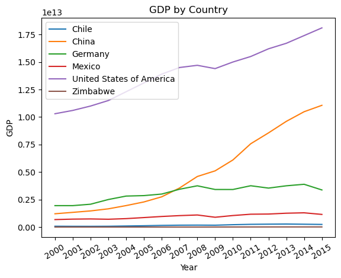

```python
for country in countries:
    country_data = df[df['Country'] == country]  # Filter data for each country
    plt.plot(country_data['Year'], country_data['GDP'], label=country)  #plot

plt.xlabel("Year") # label's and plt.show outside of loop
plt.ylabel("GDP")
plt.xticks(years, rotation=30)
plt.title("GDP by Country")
plt.legend()

plt.show()
plt.close()
```

This line graph does show the change in GDP for all of the countries. However, because the United State's GDP is so high it is very hard to see the change in some of the countries. To solve this we can plot all of the countries on their own.

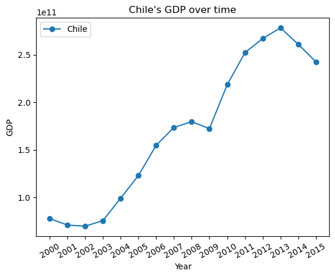

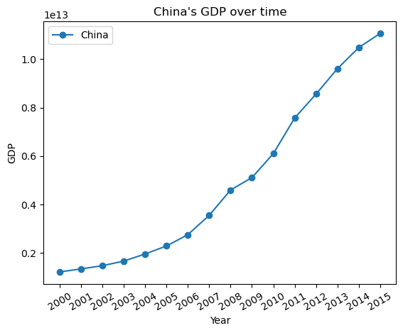

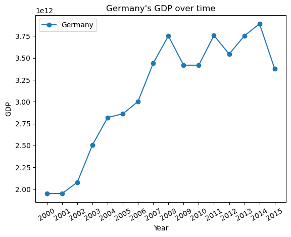

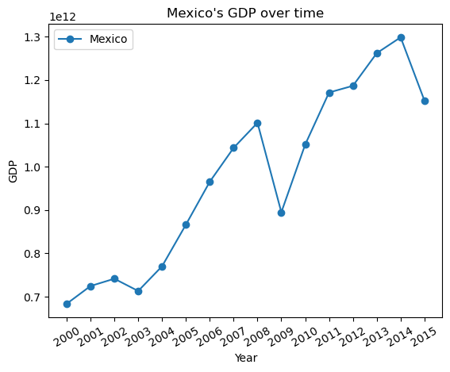

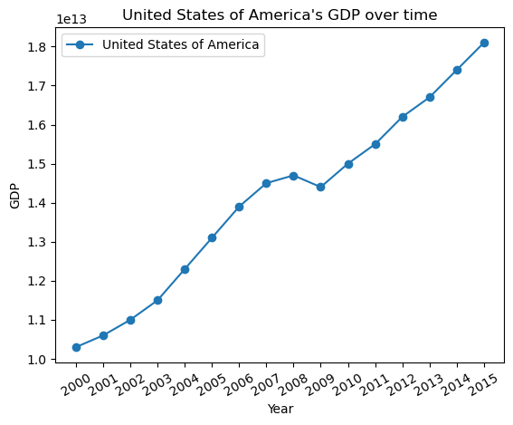

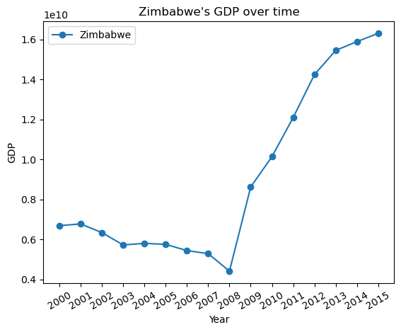

```python
for country in countries:
    country_data = df[df['Country'] == country]  # Filter data for each country
    plt.figure()
    plt.plot(country_data['Year'], country_data['GDP'], label=country, marker='o')  #plot

    plt.xlabel("Year") # label's and plt.show in loop so new graph will be made
    plt.ylabel("GDP")
    plt.xticks(years, rotation=30)
    plt.title(f"{country}'s GDP over time")
    plt.legend()

    plt.show()
    plt.close()
```

Now we can see a much clearer view of every country. And indeed all of the countries GDP's increased over time. China and the United States had the most consistent growth. `Zimbabwe, while having the lowest GDP saw explosive growth after 2008.`

## Is there a correlation between GDP and life expectancy of a country?

This is the third question from the introduction.

To answer this question we can use a scatter plot. Then statistics to determine the correlation's significance.

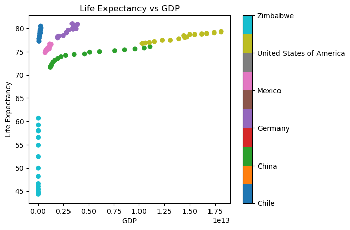

```python
countries = df['Country'].astype('category') # list to create plot colorbar and legend
colors = countries.cat.codes

plt.scatter(df["GDP"], df["Life expectancy at birth (years)"], c=colors, cmap='tab10') # makes a scatter plot
plt.xlabel("GDP")
plt.ylabel("Life Expectancy")
plt.title("Life Expectancy vs GDP")

#creates the color bar on the right with labels
colorbar = plt.colorbar()
colorbar.set_ticks([0, 1, 2, 3, 4, 5])  # 6 countries
colorbar.set_ticklabels(df['Country'].unique())

plt.show()
plt.close()
```

This scatter plot shows the change in GDP over time with respect to life expectancy.

Zimbabwe seems to have no change even though in previous sections there were clear changes. This is most likely because the other countries have much higher GDP's and life expectancy.

Let us use a Pearson coefficient to determine if there's a correlation.

```python
correlation_coefficient, p_value = st.pearsonr(df['GDP'], df['Life expectancy at birth (years)']) # returns the coefficient and p-value

print("Pearson Correlation Coefficient =",  round(correlation_coefficient,4))
print("P-value =", round(p_value,4))
```

```
Pearson Correlation Coefficient = 0.3432
P-value = 0.0006
```

A coefficient of 0.3432 indicated a weak correlation. With a p-value less than a 1% level of significance(0.01) it is statistically significant.

Though Zimbabwe as an outlier may affect this coefficient. In the scatter plot, it seems there is no change in GDP. At least on the same scale as the rest of the countries.

To potentially solve this we will use calculate the coefficient of each country on its own.

```python
years = df['Year'].unique() # list 2000-2015
countries = df["Country"].unique() # list of all countries

# loops over every country in the data, subsets it, and calculates the correlation coefficient
for country in countries:
    country_data = df[df['Country'] == country]
    correlation_coefficient, p_value =  st.pearsonr( country_data['GDP'],  country_data['Life expectancy at birth (years)'])
    print(f"Pearson's Correlation Coefficient of {country} = {round(correlation_coefficient,4)}")
    print(f"{country}'s P-value = {round(p_value,4)}")
    print()
```

```
Pearson's Correlation Coefficient of Chile = 0.9499
Chile's P-value = 0.0

Pearson's Correlation Coefficient of China = 0.9085
China's P-value = 0.0

Pearson's Correlation Coefficient of Germany = 0.9327
Germany's P-value = 0.0

Pearson's Correlation Coefficient of Mexico = 0.9322
Mexico's P-value = 0.0

Pearson's Correlation Coefficient of United States of America = 0.9817
United States of America's P-value = 0.0

Pearson's Correlation Coefficient of Zimbabwe = 0.9662
Zimbabwe's P-value = 0.0
```

While getting the correlation coefficient for every country on its own does not tell us the whole trend of all six.

It does tell us that `for each country, there is a very strong positive correlation` between GDP and life expectancy for each country. And with a p-value near 0 for all of them, they are all statistically significant.

## What is the average life expectancy in these nations?

The fourth question in the introduction.

I created a df of each countires average life expectancy. Than made a bar graph.

Bar graphs are great for comparing values. In this example, we can see the average life expectancy of every nation and how they compare to each other. Much more insightful than looking at a list of data.

```python
df_avg_life = df.groupby("Country")["Life expectancy at birth (years)"].mean().reset_index() # new df of avg life expectancy of each country
print(df_avg_life)
```

```
                    Country  Life expectancy at birth (years)
0                     Chile                          78.94375
1                     China                          74.26250
2                   Germany                          79.65625
3                    Mexico                          75.71875
4  United States of America                          78.06250
5                  Zimbabwe                          50.09375
```

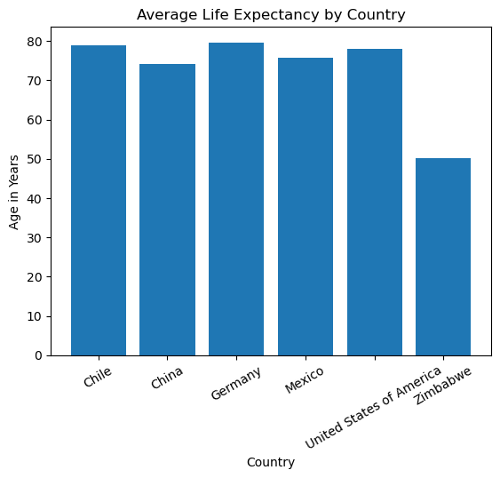

```python
plt.bar(df_avg_life["Country"], df_avg_life["Life expectancy at birth (years)"]) # makes a bar graph
plt.xlabel("Country")
plt.ylabel("Age in Years")
plt.xticks(rotation = 30)
plt.title("Average Life Expectancy by Country")
plt.show()
plt.close()
```

We can see that the overall life expectancy does seem to be around 73. Every country but Zimbabwe is higher than 70.

## What is the distribution of that life expectancy?

The fifth and final question of this project.

First I'll subset the data into a df of just life expectancy.

```python
all_life = df["Life expectancy at birth (years)"] # a of all life expectancy
all_life
```

```
0     77.3
1     77.3
2     77.8
3     77.9
4     78.0
      ...
91    54.9
92    56.6
93    58.0
94    59.2
95    60.7
Name: Life expectancy at birth (years), Length: 96, dtype: float64
```

Next, to see the distribution of life expectancy we can use a histogram.

Histograms are very useful to show a data distribution. A heat map or violin plot would be other alternatives.

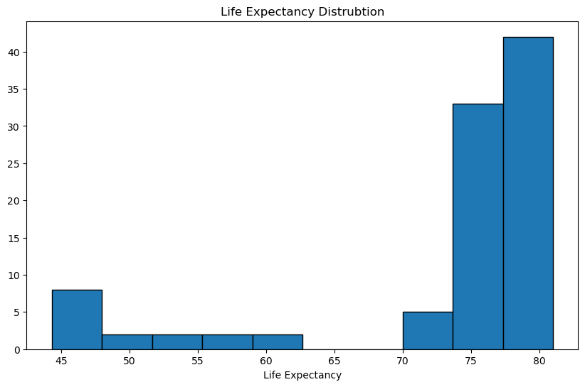

```python
plt.figure(figsize=(10, 6)) # makes a histogram
plt.hist(all_life, edgecolor='black')
plt.title('Life Expectancy Distrubtion')
plt.xlabel('Life Expectancy')
plt.show()
plt.close()
```

Most of the data is 70-80 making it left skewed. Some data falls in the 45 bin, mostly from Zimbabwe which had the lowest life expectancy.

If we look back at the scatter plot of GDP vs Life. Zimbabwe is the only nation below 70. So the 45 to about 63 bins are only Zimbabwe. The second lowest life expectancy was in China at 71.

# Conclusion

In this project, we analyzed data on GDP and life expectancy in six different countries.

## Key Findings

We were able to answer all of the questions posed in the introduction.

1. `Has life expectancy increased over time in the six nations?`

   Yes, it has increased over time for every nation. Zimbabwe had the most growth.
2. `Has GDP increased over time in the six nations?`

   The average life expectancy in every nation but Zimbabwe was in the mid-high 70s. Zimbabwe has the lowest at 50.
5. `What is the distribution of that life expectancy?`

   The data is very left-skewed. Meaning that most of the data is on the higher end. No other country other than Zimbabwe had a life expectancy lower than 70.

## Discussion

I expected life expectancy and GDP to be correlated. The wealthier a country to better healthcare it tends to have. The more it can spend on hospitals and so on. This is a very important relationship because it can help us determine the average life expectancy of a nation based on its GDP or vice versa.

However, `correlation does not imply causation. There are likely a lot of other factors that play into both GDP and life expectancy.` To get more accurate results more data than just GDP and life expectancy would be needed.

I was surprised to see the growth of Zimbabwe. While every other nation had a slow and steady increase Zimabwe has explosive growth.

I also expected that GDP and life expectancy would increase over time. The time this data is set in(2000-2015) was a time of worldwide economic growth.

## Further Analysis

This dataset included only six countries. Adding more countries with lower GDP and life expectancies similar to Zimabsbwe would help outliers not affect the data. It would also allow for more accurate findings.

When determining a correlation between GDP and life expectancy of all six counties, a better method would be to create a regression model. To better create a multiple regression model, having other variables that may affect life expectancy would be beneficial. However, that is beyond the ability of this dataset and the scope of this project.